# Chi Squared Test

```r
library(readr)
library(tidyverse)
library(mosaic)
library(pander)
GSS2012 <- read_delim("../../Data/GSS2012.csv",
                      "\t", escape_double = FALSE, trim_ws = TRUE)
```

## Background

A general survey was taken in 2012. Two questions from the survey caught my eye. “Do you happen to have in your home (or garage) any guns or revolvers?” and “Region of the Interview”. We will look at the responses of having a gun in your home Yes (1) or No (2) and their region.

## Hypothesis

The question for our data is: Does the region of the country contribute having a gun in the home? In other words, is having a gun in your home and region of the country associated?

$$H_0: \text{Gun in the home and Region of the country are independent}$$
$$H_a: \text{Gun in the home and Region of the country are associated (not independent)}$$
$$\text{Significance level: } \alpha= 0.05$$

## Analysis

Here is a table that counts all the responses people entered in according to their responses to if they have a gun in their house and what part of the country they took the survey.

```r
GS <- select(GSS2012, c(owngun, region))
GS<- filter(GS, owngun %in% c(1,2))
GS1 <-GS %>%
  mutate(Yes_or_No =
   case_when(
      GS$owngun %in% 1 ~ "Yes",
      GS$owngun %in% 2 ~ "No"),
   Region = case_when(
     GS$region %in% 1 ~ "New England",
     GS$region %in% 2 ~ "Middle Atlantic",
     GS$region %in% 3 ~ "E. Nor. Central",
     GS$region %in% 4 ~ "W. Nor. Central",
     GS$region %in% 5 ~ "South Atlantic",
     GS$region %in% 6 ~ "E. Sou. Central",
     GS$region %in% 7 ~ "W. Sou. Central",
     GS$region %in% 8 ~ "Mountain",
     GS$region %in% 9 ~ "Pacific",
   ))
survtable<-table(GS1$Yes_or_No,GS1$Region)
pander(survtable)
```

Table continues below

|  | E. Nor. Central | E. Sou. Central | Middle Atlantic | Mountain |
| --- | --- | --- | --- | --- |
| **No** | 143 | 51 | 116 | 55 |
| **Yes** | 74 | 36 | 29 | 31 |

Table continues below

|  | New England | Pacific | South Atlantic | W. Nor. Central |
| --- | --- | --- | --- | --- |
| **No** | 60 | 143 | 167 | 47 |
| **Yes** | 20 | 49 | 103 | 34 |

|  | W. Sou. Central |
| --- | --- |
| **No** | 59 |
| **Yes** | 64 |

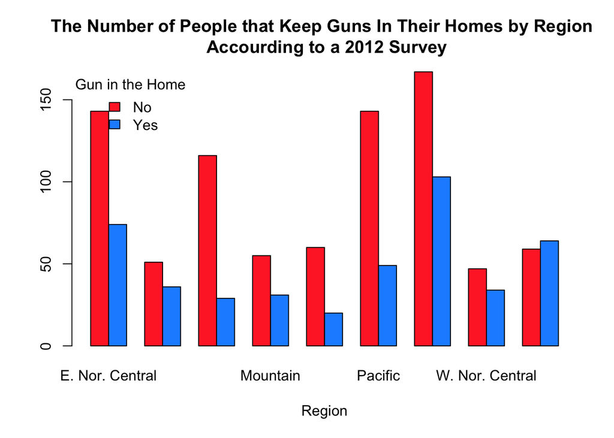

```r
barplot(survtable, beside=TRUE, col=c("firebrick1","dodgerblue"),legend.text=TRUE,args.legend = list(x="topleft",bty="n",title="Gun in the Home"),xlab="Region",main="The Number of People that Keep Guns In Their Homes by Region \n Accourding to a 2012 Survey")
```

This Bar plot gives a better representation of what the data table shows. However this doesn’t answer our question if these two variables are independent or associated. To answer this we will run a Chi-Squared Test. We will also look at the expected counts to see if the assumptions for this test are met.

```r
GSChi<-chisq.test(survtable)
pander(GSChi)
```

Pearson’s Chi-squared test: `survtable`

| Test statistic | df | P value |
| --- | --- | --- |
| 45.87 | 8 | 2.514e-07 * * * |

```r
pander(GSChi$expected)
```

Table continues below

|  | E. Nor. Central | E. Sou. Central | Middle Atlantic | Mountain |
| --- | --- | --- | --- | --- |
| **No** | 142.5 | 57.12 | 95.2 | 56.46 |
| **Yes** | 74.54 | 29.88 | 49.8 | 29.54 |

Table continues below

|  | New England | Pacific | South Atlantic | W. Nor. Central |
| --- | --- | --- | --- | --- |
| **No** | 52.52 | 126.1 | 177.3 | 53.18 |
| **Yes** | 27.48 | 65.95 | 92.74 | 27.82 |

|  | W. Sou. Central |
| --- | --- |
| **No** | 80.75 |
| **Yes** | 42.25 |

All of the expected counts are larger than 10, so the requirements are met.

Our results show a $P$-value of 2.514e-07. This $P$- value is smaller than out Significance level ($\alpha = 0.05$) so we must reject the null hypothesis.

Here are our residuals. This will let us see how much our observed counts differ from the expected counts if our null hypothesis were true.

```r
pander(GSChi$residuals)
```

Table continues below

|  | E. Nor. Central | E. Sou. Central | Middle Atlantic | Mountain |
| --- | --- | --- | --- | --- |
| **No** | 0.04487 | -0.8094 | 2.132 | -0.1944 |
| **Yes** | -0.06203 | 1.119 | -2.948 | 0.2687 |

Table continues below

|  | New England | Pacific | South Atlantic | W. Nor. Central |
| --- | --- | --- | --- | --- |
| **No** | 1.032 | 1.51 | -0.7706 | -0.8472 |
| **Yes** | -1.427 | -2.087 | 1.065 | 1.171 |

|  | W. Sou. Central |
| --- | --- |
| **No** | -2.421 |
| **Yes** | 3.346 |

The greatest difference between observed and expected counts was 3.346. This probably contributed most to our resulting p-value.

## Conclusion

Since we have to reject our null hypothesis we can conclude that the number of people that keep a gun in their home and their region are associated and not independent. This means we can assume that certain regions of the United States has an affect if people have a gun in their home.